# Linear Mixed Models in Practice

PHTH 7440 · Northeastern University

Javier Álvarez Liébana

## Today

You already know **the theory**: correlated measurements, covariance structures, random intercepts and slopes, conditional vs marginal means, BLUPs.

Today: from a fitted model to answers.

1. **Look first**: why plotting comes before modelling.
2. **Motivation** (`sleepstudy`): why a mixed model at all, seen in pictures.
3. **One group, time only** (`sleepstudy`): `emmeans`, `ggeffects`, `performance`.
4. **Bootstrap** (`sleepstudy`): when the formulas are not enough.
5. **Adding a group** (`ChickWeight`): four diets, fifty chicks, 21 Days.
6. **Group × time**: contrasts, difference curves, difference of differences.
7. **Your turn** (`Orthodont`).

## Where we are: two things to model

Every longitudinal model so far has made **two choices**: one for the **mean**, one for the **covariance**.

|  | **Mean** | **Covariance** | **In R** |
| --- | --- | --- | --- |
| Linear regression (M1–M2) | Covariates | $\sigma^2 I$: independence | `lm()` |
| RM-ANOVA (M3) | One mean per occasion, one group | Sphericity / compound symmetry | `aov(y ~ t + Error(id/t))` |
| Response profiles (M4) | Group × occasion (time as factor) | Unstructured | `gls(..., corSymm, varIdent)` |
| Parametric curves (M5) | Group × $f(t)$: line, quadratic, spline | Unstructured | `gls(y ~ group * t, ...)` |
| Covariance patterns (M6.1) | Saturated (kept fixed) | CS, AR(1), exponential… | `gls(..., corAR1 / corExp)` |
| **Mixed models (M6.2)** | **$X\beta$ (population) + $Zb_i$ (subject)** | **Induced: $ZGZ' + \sigma^2 I$** | **`lmer(y ~ t + (1 + t \| id))`** |

Mixed models are the only row where the covariance **comes from a mechanism** (subjects have their own curves) and therefore works with **any timing** of measurements.

## From questions to tools

The model is the means. The **scientific question** is answered with contrasts and plots.

| Question | Tool |
| --- | --- |
| What is the mean response at a given time? | `emmeans(m, ~ time, at = ...)` |
| How fast does it change? | `emtrends(m, ~ 1, var = "time")` |
| From which time does it differ from baseline? | `contrast(emmeans(m, ~ time), "trt.vs.ctrl")` |
| What does the model look like? | `ggeffects::ggpredict()` + `plot()` |
| Is the model reasonable? | `performance::check_model()`, `icc()`, `r2()` |
| How sure are we about σ’s or any derived number? | `confint(method = "boot")`, `bootMer()`, `PBmodcomp()` |
| *Adding a group:* do groups differ? At which times? | `emmeans(m, ~ group \| time)` + `pairs()` / `contrast()` |
| Do groups change at a different **rate**? | `emtrends(m, ~ group, var = "time")` |
| Is the change different between groups? | `contrast(..., interaction = c(group = ..., time = ...))` |

```r
install.packages(c("lme4", "lmerTest", "emmeans", "pbkrtest",
                   "ggeffects", "performance", "see"))
```

Block 1 · Look first

1

## The summary is not the data

Before any model: plot.

## Four datasets, the same numbers

```
#> # A tibble: 44 × 4
#>     obs set           x     y
#>   <int> <chr>     <dbl> <dbl>
#> 1     1 Dataset 1    10  8.04
#> 2     1 Dataset 2    10  9.14
#> 3     1 Dataset 3    10  7.46
#> 4     1 Dataset 4     8  6.58
#> 5     2 Dataset 1     8  6.95
#> 6     2 Dataset 2     8  8.14
#> 7     2 Dataset 3     8  6.77
#> 8     2 Dataset 4     8  5.76
#> # ℹ 36 more rows
```

Anscombe’s quartet (1973), available in R as `datasets::anscombe`.

| set | mean_x | var_x | mean_y | var_y | cor_xy | intercept | slope | R2 |
| --- | --- | --- | --- | --- | --- | --- | --- | --- |
| Dataset 1 | 9 | 11 | 7.5 | 4.1 | 0.8 | 3 | 0.5 | 0.7 |
| Dataset 2 | 9 | 11 | 7.5 | 4.1 | 0.8 | 3 | 0.5 | 0.7 |
| Dataset 3 | 9 | 11 | 7.5 | 4.1 | 0.8 | 3 | 0.5 | 0.7 |
| Dataset 4 | 9 | 11 | 7.5 | 4.1 | 0.8 | 3 | 0.5 | 0.7 |

Same means, same variances, same correlation, same regression line. Same data?

## Now look at them

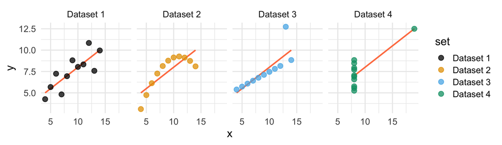

```r
ggplot(ans, aes(x, y)) +
  geom_smooth(method = "lm", se = FALSE, color = "coral", linewidth = 1) +
  geom_point(aes(color = set), size = 3, alpha = 0.75) +
  facet_wrap(~set, nrow = 1) +
  ggthemes::scale_color_colorblind() +
  theme_minimal(base_size = 16)
```

Every summary and every coefficient is identical. **Only the plot** tells you which model is wrong.

## Datasaurus dozen

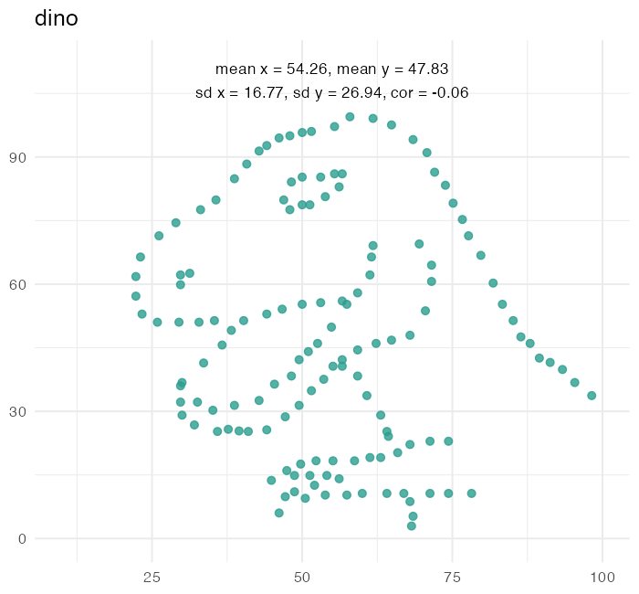

## Simpson’s paradox: the sign flips

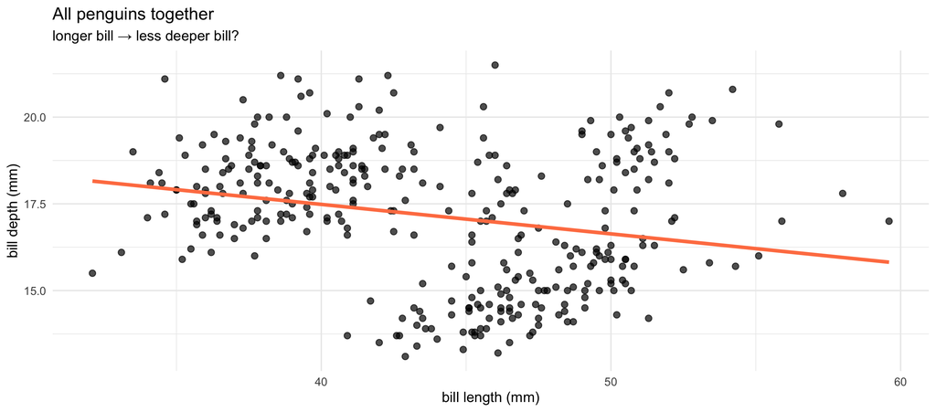

```r
library(palmerpenguins)
peng <- penguins |> drop_na(bill_length_mm, bill_depth_mm, species)
ggplot(peng, aes(bill_length_mm, bill_depth_mm)) +
  geom_point(alpha = 0.7, size = 2) +
  geom_smooth(method = "lm", se = FALSE, linewidth = 1.3, color = "coral") +
  labs(title = "All penguins together", subtitle = "longer bill → less deeper bill?", x = "bill length (mm)", y = "bill depth (mm)") +
  theme_minimal()
```

## Simpson’s paradox: the sign flips

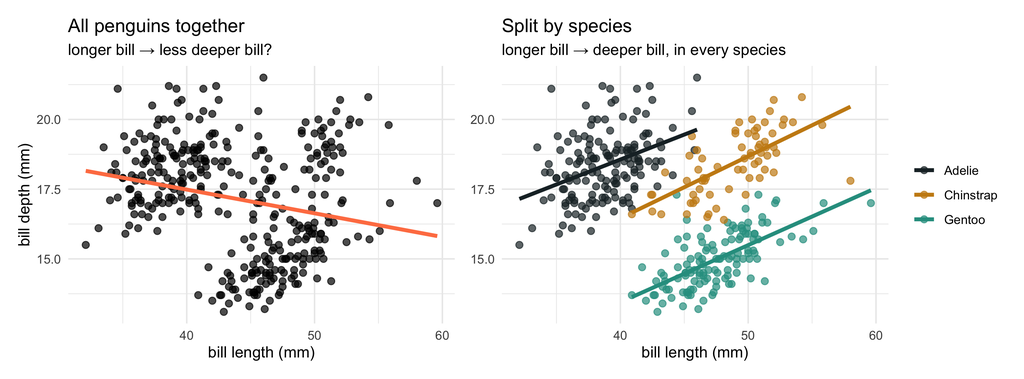

```r
ggplot(peng, aes(bill_length_mm, bill_depth_mm, color = species)) +
  geom_point(alpha = 0.7, size = 2) +
  geom_smooth(method = "lm", se = FALSE, linewidth = 1.3) +
  scale_color_manual(values = c(Adelie = "#1d2b30", Chinstrap = "#c98a14", Gentoo = "#2a9d8f")) +
  labs(title = "Split by species", subtitle = "longer bill → deeper bill, in every species", x = "bill length (mm)") +
  theme_minimal()
```

Pooled slope **< 0**, slope within every species **> 0**. A grouping variable we ignored reverses the conclusion

## Between vs within

Eight office workers took part in a **6-week touch-typing course. Once a week (weeks 0 to 5), each one completed a typing test**

```r
load(file = "typing.rda")
typing |> print(n = 7)
```

```
#> # A tibble: 48 × 5
#>   id    style  week speed errors
#>   <fct> <dbl> <int> <dbl>  <dbl>
#> 1 1        40     0  42.3  13.0
#> 2 1        40     1  41.0  12.3
#> 3 1        40     2  46.2  11.5
#> 4 1        40     3  49.3   8.98
#> 5 1        40     4  50.3   8.19
#> 6 1        40     5  55.7   5.36
#> 7 2        46     0  43.7  15.2
#> # ℹ 41 more rows
```

**Your turn.** Does typing faster go with **more** or **fewer** errors?

## Simpson inside a person: between vs within

```r
typing |> print(n = 5)
```

```
#> # A tibble: 48 × 5
#>   id    style  week speed errors
#>   <fct> <dbl> <int> <dbl>  <dbl>
#> 1 1        40     0  42.3  13.0
#> 2 1        40     1  41.0  12.3
#> 3 1        40     2  46.2  11.5
#> 4 1        40     3  49.3   8.98
#> 5 1        40     4  50.3   8.19
#> # ℹ 43 more rows
```

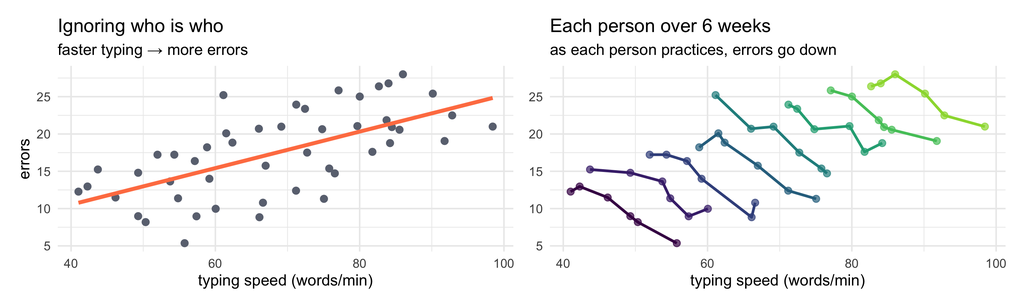

```r
p1 <- ggplot(typing, aes(speed, errors)) +
  geom_point(color = "#6b7280", size = 2) +
  geom_smooth(method = "lm", se = FALSE, color = "coral", linewidth = 1.3) +
  labs(title = "Ignoring who is who", subtitle = "faster typing → more errors",
       x = "typing speed (words/min)", y = "errors") + theme_minimal()
p2 <- ggplot(typing, aes(speed, errors, color = id)) +
  geom_line(linewidth = .9) +
  geom_point(aes(size = week), alpha = 0.7, size = 2) +
  scale_color_viridis_d(end = .85, guide = "none") +
  labs(title = "Each person over 6 weeks", subtitle = "as each person practices, errors go down",
       x = "typing speed (words/min)", y = NULL) + theme_minimal()
p1 + p2
```

**Between** people: good typists are fast *and* less accurate. **Within a person, over time**: as they speed up with practice, they make less errors. Both are true.

## Same mean profile, different stories

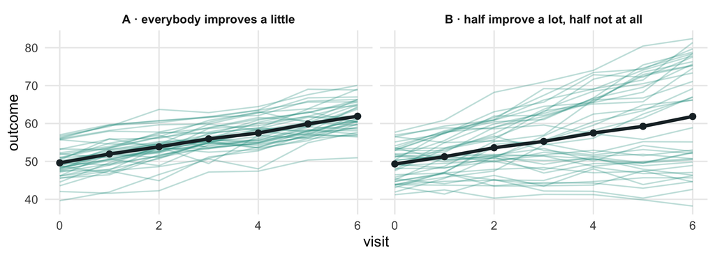

The **thick line is the same** in both panels: a table of means per visit, or the time coefficient of a fixed-effects-only model, **cannot tell A from B**.

- **A**: everybody improves by about the same amount, so the average effect describes each person well -> random intercept is enough: slopes are almost equal.
- **B**: half improve a lot (≈ 4 per visit), half not at all. The average effect (≈ 2 per visit) **happens to nobody** -> the **random-slope variance** is huge, and the fanning lines make the variance **grow over time** (heteroscedasticity).

## When the mean profile lies: drop-out

Simulated: patients leave once their marker exceeds 62 (informative drop-out).

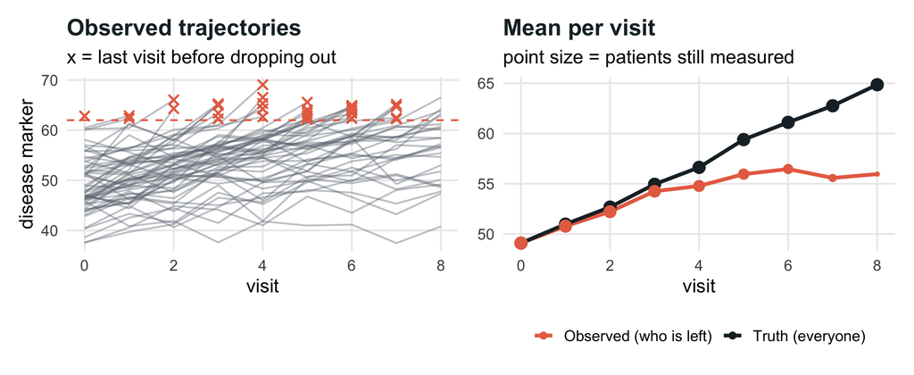

Everybody keeps getting **worse**, but the sickest leave first, so the observed mean **flattens out** and badly underestimates the decline. Always plot **who is measured when**.

## Checklist: plots before any longitudinal model

1. **Spaghetti plot**: all subjects, or a random sample if there are many. Do lines fan out? Parallel?
2. **Mean profile ± SE per group, with *n* per time**: who is still there?
3. **Facet by group**, and color by subject when there are few.
4. **Choose the time axis**: time since baseline, age, time since an event?
5. **Missingness pattern**: when do people stop being measured, and are they different?

Model what you have seen, not what you assumed.

Block 2 · Motivation: dataviz + model

2

## Why a mixed model? In pictures

`sleepstudy`: 18 truck drivers under sleep restriction (3h per night for a week), reaction time measured every day

## The data

Mean reaction time (ms) of **18 drivers** in a psychomotor vigilance task (press a button as soon as a light appears), measured **every day** of a sleep-restriction study (Belenky et al. 2003).

- Outcome: average **reaction time** (ms).
- Time: **Days** of restriction.
- 8 measurements per person → **repeated measures**.

```r
library(lme4)
sleep <-
  sleepstudy |>
  as_tibble() |>
  filter(Days >= 2) |>
  mutate("Days" = Days - 2)
sleep |>
  head(6)
```

```
#> # A tibble: 6 × 3
#>   Reaction  Days Subject
#>      <dbl> <dbl> <fct>
#> 1     251.     0 308
#> 2     321.     1 308
#> 3     357.     2 308
#> 4     415.     3 308
#> 5     382.     4 308
#> 6     290.     5 308
```

## One line for everybody? One line per person?

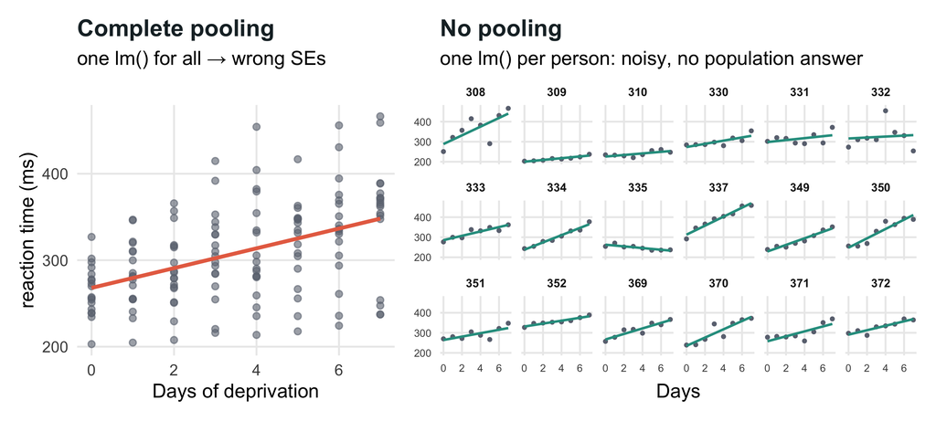

People clearly differ in **baseline** *and* in **how fast they deteriorate**. We want both the **population** answer and the **individual** curves.

## First, plot. Then, model

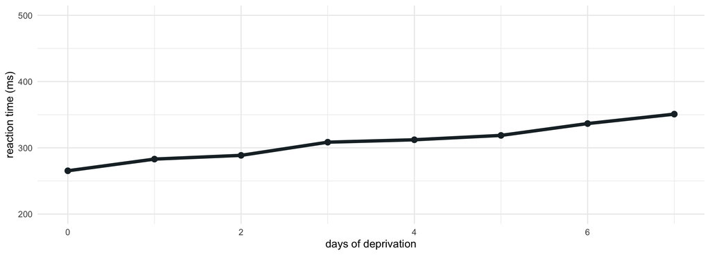

```r
ggplot(sleep, aes(Days, Reaction)) +
  stat_summary(fun = mean, geom = "line", color = "#1d2b30", linewidth = 1.6) +
  stat_summary(fun = mean, geom = "point", color = "#1d2b30", size = 2.5) +
  scale_y_continuous(limits = c(200, 500)) +
  labs(x = "days of deprivation", y = "reaction time (ms)") +
  theme_minimal()
```

If this black line were all you had, which model would you fit?

## First, plot. Then, model

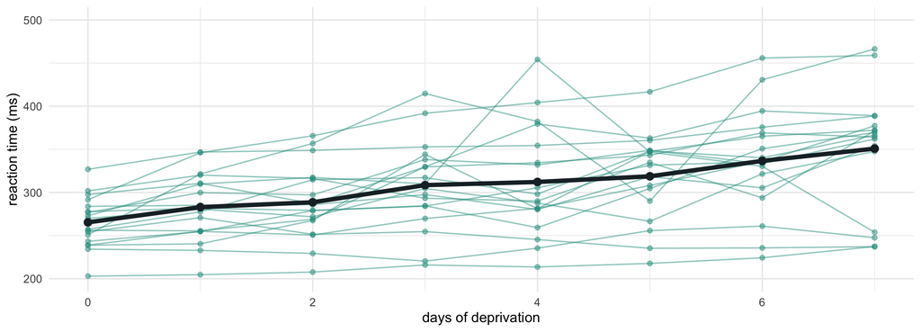

```r
ggplot(sleep, aes(Days, Reaction)) +
  geom_line(aes(group = Subject), color = "#2a9d8f", alpha = 0.5) +
  geom_point(aes(group = Subject), color = "#2a9d8f", alpha = 0.5, size = 1.5) +
  stat_summary(fun = mean, geom = "line", color = "#1d2b30", linewidth = 1.6) +
  stat_summary(fun = mean, geom = "point", color = "#1d2b30", size = 2.5) +
  scale_y_continuous(limits = c(200, 500)) +
  labs(x = "days of deprivation", y = "reaction time (ms)") +
  theme_minimal()
```

Does this average line describe anyone in particular?

## First, plot. Then, model

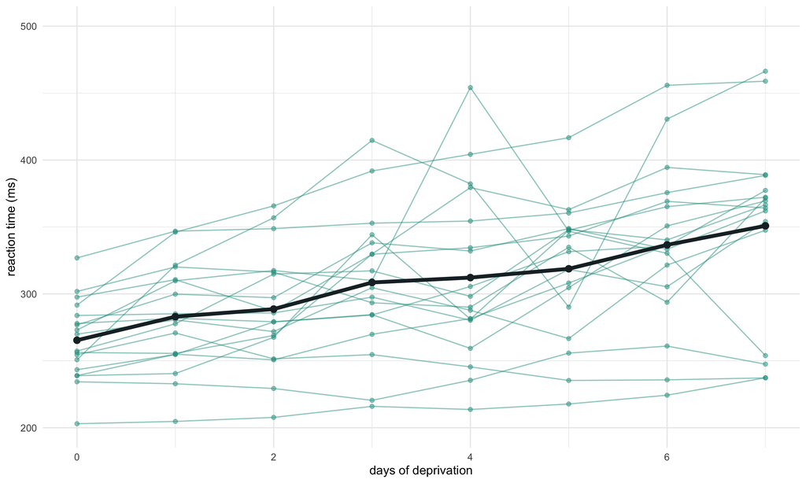

```r
ggplot(sleep, aes(Days, Reaction)) +
  geom_line(aes(group = Subject), color = "#2a9d8f", alpha = 0.5) +
  geom_point(aes(group = Subject), color = "#2a9d8f", alpha = 0.5, size = 1.5) +
  stat_summary(fun = mean, geom = "line", color = "#1d2b30", linewidth = 1.6) +
  stat_summary(fun = mean, geom = "point", color = "#1d2b30", size = 2.5) +
  scale_y_continuous(limits = c(200, 500)) +
  labs(x = "days of deprivation", y = "reaction time (ms)") +
  theme_minimal()
```

The plot already tells you the model:

- different starting points → random intercept
- different rates → random slope
- a fan that opens over time → the variance grows
- mean rises roughly in a straight line → time as a numeric, linear term
- Are starting point and rate related (do slow starters also deteriorate faster)? Hard to tell by eye, but it doesn’t look like it → let the data decide: correlated vs uncorrelated random effects

## The compromise: partial pooling

Each person has their **own line**, but those lines are assumed to be similar: they are drawn from the same **population** (with individual deviations around an average line: each person’s line borrows strength from everyone else’s). Below: i= drivers, j = Days

$$\text{Reaction}_{ij} = (\beta_1 + b_{1i}) + (\beta_2 + b_{2i})\,\text{Days}_{ij} + \varepsilon_{ij},\qquad
\begin{pmatrix} b_{1i}\\ b_{2i}\end{pmatrix} \sim N(0, G), ~ G = \begin{pmatrix} \operatorname{Var}(b_{1i}) & \operatorname{Cov}(b_{1i}, b_{2i}) \\
\operatorname{Cov}(b_{1i}, b_{2i}) & \operatorname{Var}(b_{2i}) \end{pmatrix}$$

- $\beta_1, \beta_2$: **population** line (fixed effects).
- $b_{1i}, b_{2i}$: how person $i$ **deviates** from it (random effects).
- $G$: how much people vary (σ’s and their correlation).

## Three candidates

```r
# random intercept
m_ri <- lmer(Reaction ~ Days + (1 | Subject), data = sleep)
# random intercept + random slope
m_rs <- lmer(Reaction ~ Days + (1 + Days | Subject), data = sleep)
# random intercept + random slope (but uncorrelated)
m_ind <- lmer(Reaction ~ Days + (Days || Subject), data = sleep)
```

```
Reaction ~ Days + (1 + Days | Subject)
           ────    ────────   ───────
            │         │          └─ grouping: "per Subject" → one bᵢ per person
            │         └──────────── which coefficients vary by person:
            │                       1 = intercept (b₁ᵢ), Days = slope (b₂ᵢ)
            └────────────────────── fixed part: β₁ + β₂·Days (the 1 is implicit)
```

| Formula | Meaning | Implied $G$ |
| --- | --- | --- |
| `(1 \| Subject)` | random intercept only: parallel lines | $g_{11}$ only (compound symmetry, M3) |
| `(1 + Days \| Subject)` | random intercept + slope, **correlated** | full $2 \times 2$ |
| `(Days \|\| Subject)` | random intercept + slope, **independent** | diagonal, $g_{12} = 0$ |

## The `summary()` wall

```r
summary(m_ri)$coefficients |> round(3)
```

```
#>             Estimate Std. Error     df t value Pr(>|t|)
#> (Intercept)   267.97     10.871  22.15   24.65        0
#> Days           11.44      1.099 125.00   10.40        0
```

```r
summary(m_ind)$coefficients |> round(3)
```

```
#>             Estimate Std. Error    df t value Pr(>|t|)
#> (Intercept)   267.97      8.464 18.11  31.659        0
#> Days           11.44      1.890 18.11   6.052        0
```

```r
summary(m_rs)$coefficients |> round(3)
```

```
#>             Estimate Std. Error df t value Pr(>|t|)
#> (Intercept)   267.97      8.266 17  32.418        0
#> Days           11.44      1.845 17   6.197        0
```

Fixed effects (model 1): $\beta_1 \sim N(267.97, 10.871)$ and $\beta_2 \sim N(11.44, 1.099)$

Fixed effects (model 2): $\beta_1 \sim N(267.97, 8.464)$ and $\beta_2 \sim N(11.44, 1.890)$

Fixed effects (model 3): $\beta_1 \sim N(267.97, 8.266)$ and $\beta_2 \sim N(11.44, 1.845)$

Same estimates in all three models; what changes is the uncertainty. Ignoring that people deteriorate at different rates (`m_ri`) makes the slope look much more precise than it is: SE 1.1 vs 1.9, df 125 vs 17. For the average rate, the sample size is 18 people, not 144 observations.

## Three candidates

```r
# random intercept
m_ri <- lmer(Reaction ~ Days + (1 | Subject), data = sleep)
# random intercept + random slope
m_rs <- lmer(Reaction ~ Days + (1 + Days | Subject), data = sleep)
# random intercept + random slope (but uncorrelated)
m_ind <- lmer(Reaction ~ Days + (Days || Subject), data = sleep)
anova(m_ri, m_rs, m_ind)
```

```
#> Data: sleep
#> Models:
#> m_ri: Reaction ~ Days + (1 | Subject)
#> m_ind: Reaction ~ Days + (Days || Subject)
#> m_rs: Reaction ~ Days + (1 + Days | Subject)
#>       npar  AIC  BIC logLik deviance Chisq Df Pr(>Chisq)
#> m_ri     4 1446 1458   -719     1438
#> m_ind    5 1424 1438   -707     1414 24.98  1    5.8e-07 ***
#> m_rs     6 1425 1443   -707     1413  0.35  1       0.55
#> ---
#> Signif. codes:  0 '***' 0.001 '**' 0.01 '*' 0.05 '.' 0.1 ' ' 1
```

**And the winner is…**

- m_ri → m_ind (add random slopes): p < 0.001 (AIC 1446 → 1424). **Own slopes are needed: people deteriorate at different rates**
- m_ind → m_rs (add correlation): p = 0.55 (AIC 1424 → 1425). **Correlation adds nothing**: knowing where someone starts tells us nothing about how fast they deteriorate.

## Reading the output in plain words

`coef() = fixef() + ranef()`

```r
summary(m_ind)$coefficients |> round(3)
```

```
#>             Estimate Std. Error    df t value Pr(>|t|)
#> (Intercept)   267.97      8.464 18.11  31.659        0
#> Days           11.44      1.890 18.11   6.052        0
```

```r
fixef(m_ind)
```

```
#> (Intercept)        Days
#>      267.97       11.44
```

```r
VarCorr(m_ind)
```

```
#>  Groups    Name        Std.Dev.
#>  Subject   (Intercept) 31.94
#>  Subject.1 Days         6.99
#>  Residual              25.43
```

```r
ranef(m_ind)$Subject |> head(5)
```

```
#>     (Intercept)   Days
#> 308      23.651  8.748
#> 309     -60.343 -7.807
#> 310     -39.640 -7.323
#> 330       1.984 -2.528
#> 331      20.253 -4.180
```

```r
coef(m_ind)$Subject |> head(5)
```

```
#>     (Intercept)   Days
#> 308       291.6 20.183
#> 309       207.6  3.629
#> 310       228.3  4.112
#> 330       270.0  8.907
#> 331       288.2  7.255
```

**Your turn:**

1. How fast does the **average** driver react at baseline? How much slower each day?
2. How much do drivers differ in their **baseline**? And in their **rate**?
3. Driver **308**: baseline and rate? Check that `coef()` = `fixef()` + `ranef()`.
4. Which is the distribution of the slope?
5. What is bigger: differences **between drivers** at baseline, or **day-to-day noise** within a driver?

## Uncertainty, in one picture

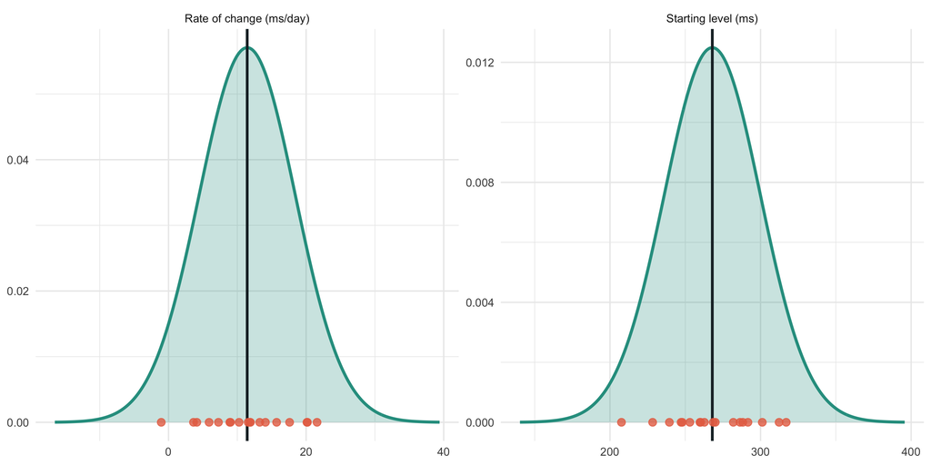

## Three lines per person

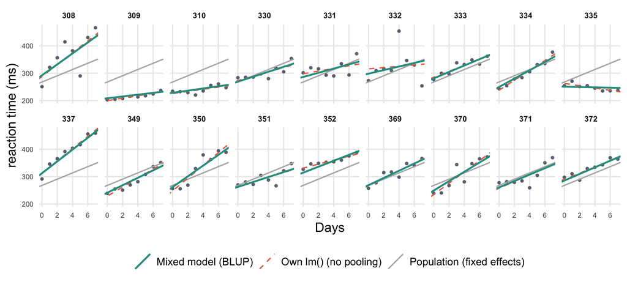

```r
ind <- sleep |>
  group_by(Subject) |>
  summarise(fit = list(lm(Reaction ~ Days))) |>
  mutate(a = map_dbl(fit, ~ coef(.x)[1]), s = map_dbl(fit, ~ coef(.x)[2]))
blup <- coef(m_rs)$Subject |>
  rownames_to_column("Subject") |>
  rename(a_blup = `(Intercept)`, s_blup = Days)
lines_df <- ind |>
  select(Subject, a, s) |>
  left_join(blup, by = "Subject")

ggplot(sleep, aes(Days, Reaction)) +
  geom_point(color = "#6b7280", size = 1) +
  geom_abline(aes(intercept = b[1], slope = b[2], color = "Population (fixed effects)"),
              linewidth = .7, data = lines_df) +
  geom_abline(aes(intercept = a, slope = s, color = "Own lm() (no pooling)"),
              linetype = "dashed", linewidth = .7, data = lines_df) +
  geom_abline(aes(intercept = a_blup, slope = s_blup, color = "Mixed model (BLUP)"),
              linewidth = 1, data = lines_df) +
  facet_wrap(~ Subject, ncol = 9) +
  scale_color_manual(NULL, values = c("Population (fixed effects)" = "grey70",
                                       "Own lm() (no pooling)" = counter,
                                       "Mixed model (BLUP)" = "#2a9d8f")) +
  labs(x = "Days", y = "reaction time (ms)") +
  theme(strip.text = element_text(size = 9), axis.text = element_text(size = 8))
```

## Shrinkage, in one picture

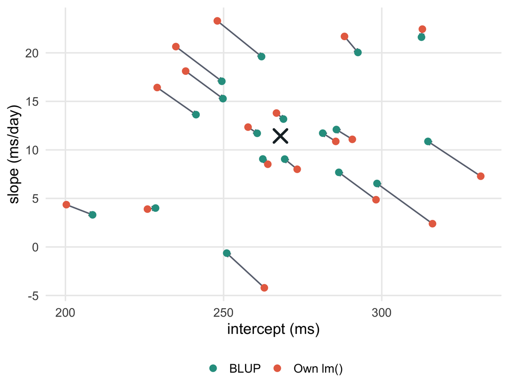

Every arrow points **towards the population mean** (✕).

- Extreme, noisy individual estimates are **pulled in**.
- How much? It depends on how noisy the person’s data are compared with how much people differ ($G$ vs $\sigma^2$).
- This is the BLUP / empirical Bayes formula from M6.2, at work.

Block 3 · Answers

3

## emmeans

Let the model do the arithmetic (Lenth 2024)

You never touch the coefficients. You say **where** (which days) and **what** (means, differences, slopes); `emmeans` builds the combinations, SEs, df and p-values.

## Before `emmeans`: by hand

```r
summary(m_ind)$coefficients |> round(2)
```

```
#>             Estimate Std. Error    df t value Pr(>|t|)
#> (Intercept)   267.97       8.46 18.11   31.66        0
#> Days           11.44       1.89 18.11    6.05        0
```

**Your turn**, with this table only:

1. Expected reaction time of the **average driver** on day 0, day 3 and day 7?
2. How much **slower** is the average driver on day 7 than on day 0?
3. And the **standard error** of each of those numbers?

## Step 1 · Expected reaction time on given days

```r
emm_sl <- emmeans(m_ind, ~ Days, at = list(Days = c(0, 3, 7)))
```

```
#>  Days emmean    SE   df lower.CL upper.CL
#>     0    268  8.46 18.2      250      286
#>     3    302  9.26 22.3      283      322
#>     7    348 14.31 21.8      318      378
#>
#> Degrees-of-freedom method: kenward-roger
#> Confidence level used: 0.95
```

```r
# Tukey (reverse = later minus earlier)
pairs(emm_sl, reverse = TRUE)
```

```
#>  contrast      estimate    SE   df t.ratio p.value
#>  Days3 - Days0     34.3  5.67 18.2   6.052  <.0001
#>  Days7 - Days0     80.0 13.23 18.2   6.052  <.0001
#>  Days7 - Days3     45.7  7.56 18.2   6.052  <.0001
#>
#> Degrees-of-freedom method: kenward-roger
#> P value adjustment: tukey method for comparing a family of 3 estimates
```

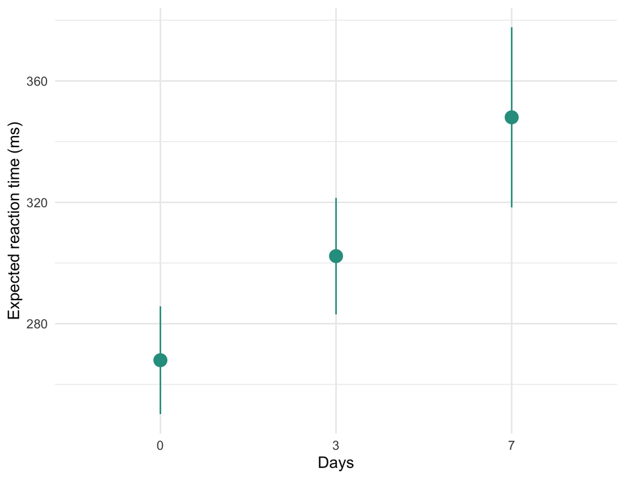

```r
emm_sl |> summary() |> as_tibble() |>
  ggplot(aes(x = factor(Days), y = emmean)) +
  geom_pointrange(aes(ymin = lower.CL, ymax = upper.CL), color = "#2a9d8f", size = 0.8) +
  labs(x = "Days", y = "Expected reaction time (ms)") +
  theme_minimal()
```

## Before `emtrends`: by hand

**Your turn**, with the same `summary(m_ind)` table:

1. What is the **average rate of deterioration** (ms/day)?

Extra. Compute its **95 % CI** by hand. (Hint: estimate ± `qt(0.975, df)` · SE.)

## Step 2 · How fast? `emtrends`

```r
emtrends(m_ind, ~ 1, var = "Days")
```

```
#>  1       Days.trend   SE   df lower.CL upper.CL
#>  overall       11.4 1.89 18.2     7.47     15.4
#>
#> Degrees-of-freedom method: kenward-roger
#> Confidence level used: 0.95
```

The **average rate of deterioration is 11.4 ms/day**, with its CI and Kenward-Roger df (≈ 17, one per driver minus one, not 144 observations). Same number as `fixef()`, but with uncertainty attached (7.47 – 15.4: 95 % CI for the average rate)

## Step 3 · From which day? Time as a factor

```r
sleep_f <- sleep |> mutate(Days_f = factor(Days))
m_fac <- lmer(Reaction ~ Days_f + (1 | Subject), data = sleep_f)
vs_base <- contrast(emmeans(m_fac, ~ Days_f), method = "trt.vs.ctrl", ref = 1)
confint(vs_base)
```

```
#>  contrast          estimate   SE  df lower.CL upper.CL
#>  Days_f1 - Days_f0     17.6 10.2 119    -9.66     44.9
#>  Days_f2 - Days_f0     23.3 10.2 119    -4.01     50.6
#>  Days_f3 - Days_f0     43.2 10.2 119    15.86     70.5
#>  Days_f4 - Days_f0     46.8 10.2 119    19.52     74.1
#>  Days_f5 - Days_f0     53.4 10.2 119    26.10     80.7
#>  Days_f6 - Days_f0     71.3 10.2 119    43.97     98.6
#>  Days_f7 - Days_f0     85.5 10.2 119    58.20    112.8
#>
#> Degrees-of-freedom method: kenward-roger
#> Confidence level used: 0.95
#> Conf-level adjustment: dunnettx method for 7 estimates
```

Why time as a factor?

With numeric Days there is one line: every “day k − day 0” is just $k \beta_2$, so the line, not the data, decides “from which day”. With `factor(Days)` each day gets its own free mean (no shape assumed), so each day can be compared with baseline.

## Step 3 · From which day? Time as a factor

```r
sleep_f <- sleep |> mutate(Days_f = factor(Days))
m_fac <- lmer(Reaction ~ Days_f + (1 | Subject), data = sleep_f)
vs_base <- contrast(emmeans(m_fac, ~ Days_f), method = "trt.vs.ctrl", ref = 1)
vs_base
```

```
#>  contrast          estimate   SE  df t.ratio p.value
#>  Days_f1 - Days_f0     17.6 10.2 119   1.723  0.3647
#>  Days_f2 - Days_f0     23.3 10.2 119   2.277  0.1282
#>  Days_f3 - Days_f0     43.2 10.2 119   4.219  0.0003
#>  Days_f4 - Days_f0     46.8 10.2 119   4.577  0.0001
#>  Days_f5 - Days_f0     53.4 10.2 119   5.219  <.0001
#>  Days_f6 - Days_f0     71.3 10.2 119   6.967  <.0001
#>  Days_f7 - Days_f0     85.5 10.2 119   8.357  <.0001
#>
#> Degrees-of-freedom method: kenward-roger
#> P value adjustment: dunnettx method for 7 tests
```

Why no random slope?

With a factor there is no single slope, only 7 dummies. `(1 | Subject)` gives the mixed-model version of RM-ANOVA (compound symmetry).

## Step 3 · From which day? Time as a factor

```r
sleep_f <- sleep |> mutate(Days_f = factor(Days))
m_fac <- lmer(Reaction ~ Days_f + (1 | Subject), data = sleep_f)
vs_base <- contrast(emmeans(m_fac, ~ Days_f), method = "trt.vs.ctrl", ref = 1)
confint(vs_base)
```

```
#>  contrast          estimate   SE  df lower.CL upper.CL
#>  Days_f1 - Days_f0     17.6 10.2 119    -9.66     44.9
#>  Days_f2 - Days_f0     23.3 10.2 119    -4.01     50.6
#>  Days_f3 - Days_f0     43.2 10.2 119    15.86     70.5
#>  Days_f4 - Days_f0     46.8 10.2 119    19.52     74.1
#>  Days_f5 - Days_f0     53.4 10.2 119    26.10     80.7
#>  Days_f6 - Days_f0     71.3 10.2 119    43.97     98.6
#>  Days_f7 - Days_f0     85.5 10.2 119    58.20    112.8
#>
#> Degrees-of-freedom method: kenward-roger
#> Confidence level used: 0.95
#> Conf-level adjustment: dunnettx method for 7 estimates
```

Why each piece of code do?

- `emmeans(m_fac, ~ Days_f)`: the estimated mean reaction time on each day (8 means, with SE).
- `contrast()`: differences between those means, with SE, t-test and adjusted p-value.
- `method = "trt.vs.ctrl"`: each level vs a reference (day 1 − day 0, …, day 7 − day 0). Others: “pairwise”, “consec”.
- `ref = 1`: the reference is the 1st level (day 0).
- `confint()`: confidence intervals for those differences (Dunnett-adjusted), instead of p-values.

Days 1–2: not clearly different from baseline (CIs include 0). From day 3 on, reaction time is clearly slower, and the gap keeps growing: ≈ 43 ms on day 3, ≈ 86 ms on day 7 (Dunnett-adjusted 95 % CIs).

## Step 3 · From which day? Time as a factor

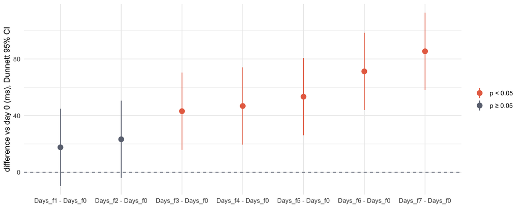

```r
confint(vs_base) |>
  as_tibble() |>
  left_join(as_tibble(vs_base) |> select(contrast, p.value), by = "contrast") |>
  mutate(sig = if_else(p.value < .05, "p < 0.05", "p ≥ 0.05"), contrast = fct_inorder(contrast)) |>
  ggplot(aes(contrast, estimate, color = sig)) +
  geom_hline(yintercept = 0, linetype = "dashed", color = "#6b7280") +
  geom_pointrange(aes(ymin = lower.CL, ymax = upper.CL), size = .6) +
  scale_color_manual(NULL, values = c("p < 0.05" = counter, "p ≥ 0.05" = "#6b7280")) +
  labs(x = NULL, y = "difference vs day 0 (ms), Dunnett 95% CI") +
  theme_minimal()
```

Days 1–2: not clearly different from baseline (CIs include 0). From day 3 on, reaction time is clearly slower.

Block 4 · Uncertainty

4

## The bootstrap

When the formulas are not enough.

## Why? Three cracks in the usual inference

1. **No exact df** for fixed effects: Satterthwaite/KR are approximations, shaky with few subjects (18 here).
2. **Variance components** (σ’s) are skewed and cannot be negative → Wald CIs are bad.
3. **“Do I need the random slope?”** tests whether a variance $g_{22} = 0$, on the **boundary**, but a variance cannot be negative → the usual χ² p-value is then too large (conservative)

## Parametric bootstrap: the idea

No df, no normal approximation for θ̂: the **sampling distribution is simulated** from the fitted model. θ can be a σ, a prediction, a contrast, an ICC…

## CIs for the σ’s: profile vs bootstrap

```r
ci_prof <- confint(m_ind, oldNames = FALSE)
ci_prof
```

```
#>                          2.5 % 97.5 %
#> sd_(Intercept)|Subject  20.633  47.26
#> sd_Days|Subject          4.379  10.46
#> sigma                   22.401  29.16
#> (Intercept)            250.949 284.99
#> Days                     7.636  15.23
```

```r
set.seed(2026)
ci_boot <- confint(m_ind, method = "boot",
                   nsim = 500, oldNames = FALSE)
ci_boot
```

```
#>                          2.5 %  97.5 %
#> sd_(Intercept)|Subject  18.641  45.784
#> sd_Days|Subject          3.458   9.884
#> sigma                   22.327  29.078
#> (Intercept)            252.091 285.039
#> Days                     7.893  15.711
```

SD of the slopes: **3.5–9.9 ms/day** (bootstrap). Drivers clearly differ in how fast they deteriorate; how much exactly is quite uncertain with 18 people.

## Any derived quantity: `bootMer()`

**Example: estimate the % of drivers who worsen by more than 20 ms/day** (personal slope), and how uncertain that number is. **Why bootstrap?** This % is not a parameter but a combination of $\hat\beta_2$ and $\hat\sigma$. There is no formula for its SE; the bootstrap gets it by simulation.

```r
# % of drivers worsening > 20 ms/day
pct_fast <- function(fit) {
  b <- fixef(fit)["Days"]
  vc <- VarCorr(fit) |> as_tibble()
  s  <- vc$sdcor[which(vc$var1 == "Days")]
  100 * (1 - pnorm(20, b, s))
}
set.seed(2026)
bt_sl <- bootMer(m_ind, pct_fast, nsim = 1000)
bt_sl$t0
```

```
#> [1] 11.02
```

```r
quantile(bt_sl$t, c(.025, .975))
```

```
#>    2.5%   97.5%
#>  0.3958 27.8685
```

`pct_fast()` computes it from a fitted model:

- `b`: average slope (11.44 ms/day).
- `s`: SD of slopes across drivers (6.99).

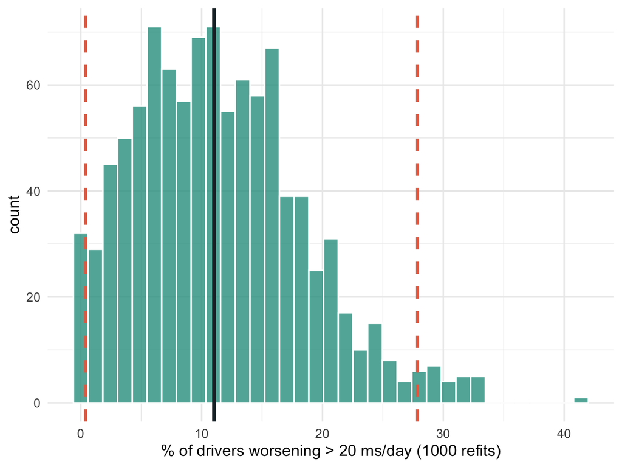

`bootMer(m_ind, pct_fast, nsim = 1000)`: simulates 1000 new studies of 18 drivers from the model, refits each one and recomputes `pct_fast()’. Result: 1000 percentages.

The resampling unit is the subject, not the observation.

Block 5 · Practice

5

## ChickWeight: your turn

Same workflow as `sleepstudy`, new data: 50 chicks, 4 diets, 21 days.

## The data

**50 chicks** on **4 diets**, weighed (g) on days 0, 2, 4, …, 20, 21 (Crowder and Hand 1990).

```r
chicks |>
  group_by(Diet) |>
  summarise(chicks = n_distinct(Chick),
            measurements = n())
```

```
#> # A tibble: 4 × 3
#>   Diet  chicks measurements
#>   <fct>  <int>        <int>
#> 1 1         20          220
#> 2 2         10          120
#> 3 3         10          120
#> 4 4         10          118
```

- **Unbalanced**: Diet 1 has twice as many chicks.
- **Drop-out**: some chicks die (chick 18 has only 2 weights).
- Growth is **not** a straight line.

Unbalanced + missing + curved: what response profiles (M4) struggle with and mixed models handle.

## Exercise

1. **Spaghetti plot**, one panel per `Diet`. Different starts? Different rates? A fan?
2. **Mean profile ± 2 SE** per diet. Line or curve?
3. **Candidates**: random intercept vs intercept + slope (correlated / uncorrelated). Then linear vs quadratic time.
4. Compare with `anova()`. Which one do you keep, and why?
5. `fixef()`, `VarCorr()`: how much do chicks differ in growth rate?
6. `ranef()`, `coef()`: which chick grows fastest? Slowest?

## 1. Look first: spaghetti plot

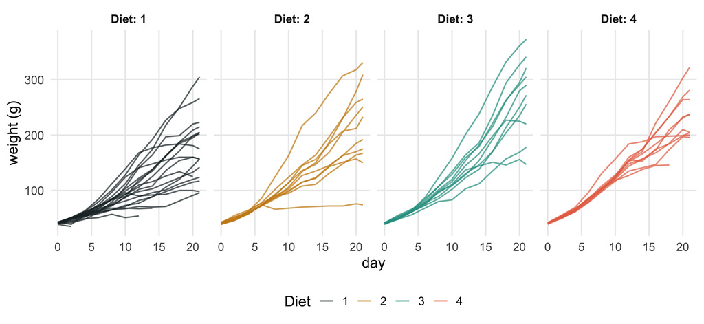

```r
pal_diet <- c("1" = "#1d2b30", "2" = ghost, "3" = "#2a9d8f", "4" = counter)
ggplot(chicks, aes(Time, weight, group = Chick, color = Diet)) +
  geom_line(alpha = .7) +
  facet_wrap(~ Diet, nrow = 1, labeller = label_both) +
  scale_color_manual(values = pal_diet) +
  labs(x = "day", y = "weight (g)")
```

## 2. Look first: mean profiles

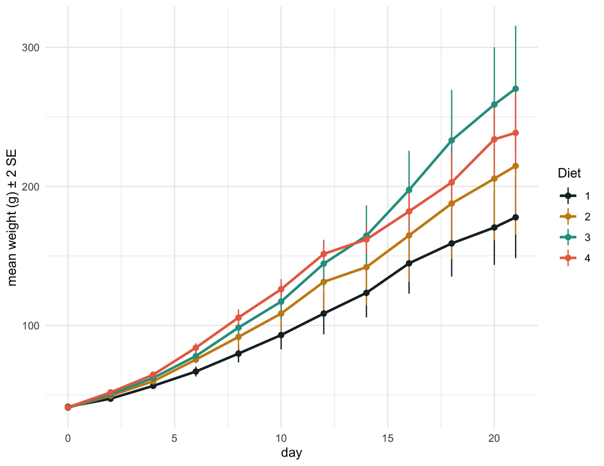

```r
chicks |>
  summarise(m = mean(weight), se = sd(weight) / sqrt(n()),
            .by = c(Diet, Time)) |>
  ggplot(aes(Time, m, color = Diet)) +
  geom_line(linewidth = 1) +
  geom_pointrange(aes(ymin = m - 2 * se, ymax = m + 2 * se), size = .3) +
  scale_color_manual(values = pal_diet) +
  labs(x = "day", y = "mean weight (g) ± 2 SE") +
  theme_minimal()
```

```r
chicks |>
  filter(Time %in% c(0, 6, 12, 21)) |>
  summarise(sd = sd(weight), .by = Time)
```

```
#> # A tibble: 4 × 2
#>    Time    sd
#>   <dbl> <dbl>
#> 1     0  1.13
#> 2     6  9.01
#> 3    12 34.1
#> 4    21 71.5
```

SD goes from **≈1 g** to **≈70 g**. Correlation **and** heteroscedasticity

## 3. Building the model: three candidates

Mean: diet × time (line or quadratic). Covariance: random intercept, or intercept + slope.

```r
m0 <- lmer(weight ~ Time * Diet + (0 + Time | Chick), data = chicks)
m1 <- lmer(weight ~ Time * Diet + (1 | Chick), data = chicks)
m2 <- lmer(weight ~ Time * Diet + (1 + Time | Chick), data = chicks)
m3 <- lmer(weight ~ (Time + I(Time^2)) * Diet + (1 + Time | Chick), data = chicks)
```

**m0** · random slope only: common start, own rate
$$Y_{ij} = \alpha_{d(i)} + (\beta_{d(i)} + b_{2i})\, t_{ij} + \varepsilon_{ij},
\qquad b_{2i} \sim N(0, g_{22})$$

**m1** · random intercept only: own start, common rate
$$Y_{ij} = (\alpha_{d(i)} + b_{1i}) + \beta_{d(i)}\, t_{ij} + \varepsilon_{ij},
\qquad b_{1i} \sim N(0, g_{11})$$

**m2** · random intercept + slope (correlated)
$$Y_{ij} = (\alpha_{d(i)} + b_{1i}) + (\beta_{d(i)} + b_{2i})\, t_{ij} + \varepsilon_{ij},
\qquad \begin{pmatrix} b_{1i} \\ b_{2i} \end{pmatrix} \sim N\!\left(\mathbf{0}, \begin{pmatrix} g_{11} & g_{12} \\ g_{12} & g_{22} \end{pmatrix}\right)$$

**m3** · as m2 + a quadratic curve per diet
$$Y_{ij} = (\alpha_{d(i)} + b_{1i}) + (\beta_{d(i)} + b_{2i})\, t_{ij} + \gamma_{d(i)}\, t_{ij}^2 + \varepsilon_{ij},
\qquad \begin{pmatrix} b_{1i} \\ b_{2i} \end{pmatrix} \sim N(\mathbf{0}, G)$$

## 4. Comparing candidates

```r
anova(m1, m0, m2, m3)
```

```
#> Data: chicks
#> Models:
#> m1: weight ~ Time * Diet + (1 | Chick)
#> m0: weight ~ Time * Diet + (0 + Time | Chick)
#> m2: weight ~ Time * Diet + (1 + Time | Chick)
#> m3: weight ~ (Time + I(Time^2)) * Diet + (1 + Time | Chick)
#>    npar  AIC  BIC logLik deviance Chisq Df Pr(>Chisq)
#> m1   10 5508 5552  -2744     5488
#> m0   10 4908 4952  -2444     4888 599.6  0
#> m2   12 4824 4877  -2400     4800  88.2  2     <2e-16 ***
#> m3   16 4678 4747  -2323     4646 154.5  4     <2e-16 ***
#> ---
#> Signif. codes:  0 '***' 0.001 '**' 0.01 '*' 0.05 '.' 0.1 ' ' 1
```

```r
compare_performance(m1, m0, m2, m3) |>
  as_tibble() |>
  select(Name, AIC, BIC, R2_marginal, R2_conditional, ICC, RMSE)
```

```
#> # A tibble: 4 × 7
#>   Name    AIC   BIC R2_marginal R2_conditional   ICC  RMSE
#>   <chr> <dbl> <dbl>       <dbl>          <dbl> <dbl> <dbl>
#> 1 m1    5508. 5552.       0.765          0.873 0.459  24.3
#> 2 m0    4909. 4952.       0.750          0.961 0.845  13.4
#> 3 m2    4825. 4877.       0.747          0.968 0.873  12.1
#> 4 m3    4678. 4748.       0.757          0.976 0.903  10.2
```

## The `summary()` wall

```r
summary(m3)$coefficients |> round(3)
```

```
#>                 Estimate Std. Error     df t value Pr(>|t|)
#> (Intercept)       37.862      3.125  65.38  12.117    0.000
#> Time               4.917      0.846  75.70   5.809    0.000
#> I(Time^2)          0.067      0.019 487.19   3.475    0.001
#> Diet2             -0.182      5.399  64.80  -0.034    0.973
#> Diet3              0.962      5.399  64.80   0.178    0.859
#> Diet4             -1.622      5.402  64.94  -0.300    0.765
#> Time:Diet2         0.893      1.453  73.71   0.614    0.541
#> Time:Diet3         0.140      1.453  73.71   0.097    0.923
#> Time:Diet4         3.258      1.456  74.25   2.237    0.028
#> I(Time^2):Diet2    0.063      0.032 479.92   1.975    0.049
#> I(Time^2):Diet3    0.229      0.032 479.92   7.176    0.000
#> I(Time^2):Diet4   -0.003      0.032 480.98  -0.097    0.922
```

- `Diet k`: difference vs Diet 1 at day 0 (≈ 0: same start)
- `Time`: only for Diet 1 (the reference)
- `Time:Diet k`: the difference in slope between Diet k and Diet 1 at day 0.
- `I(Time^2):Diet k`: the difference in curvature between Diet k and Diet 1 (how much more (or less) Diet k’s growth rate accelerates each day?)

## Your turn: read the coefficients

```r
summary(m3)$coefficients |> round(3)
```

```
#>                 Estimate Std. Error     df t value Pr(>|t|)
#> (Intercept)       37.862      3.125  65.38  12.117    0.000
#> Time               4.917      0.846  75.70   5.809    0.000
#> I(Time^2)          0.067      0.019 487.19   3.475    0.001
#> Diet2             -0.182      5.399  64.80  -0.034    0.973
#> Diet3              0.962      5.399  64.80   0.178    0.859
#> Diet4             -1.622      5.402  64.94  -0.300    0.765
#> Time:Diet2         0.893      1.453  73.71   0.614    0.541
#> Time:Diet3         0.140      1.453  73.71   0.097    0.923
#> Time:Diet4         3.258      1.456  74.25   2.237    0.028
#> I(Time^2):Diet2    0.063      0.032 479.92   1.975    0.049
#> I(Time^2):Diet3    0.229      0.032 479.92   7.176    0.000
#> I(Time^2):Diet4   -0.003      0.032 480.98  -0.097    0.922
```

Using the `summary(m3)` table:

1. What is the growth rate of **Diet 1 at day 0**? Which coefficient(s) do you need?
2. What is the growth rate of **Diets 2, 3 and 4 at day 0**?
3. Which diet grows fastest **at the start**?
4. What is the growth rate of **Diets 1, 3 and 4 at day 10**? (Hint: with a quadratic curve, the rate at day *t* is slope + 2 · curvature · *t*.)
5. Which diet grows fastest **at day 10**? Why did the ranking change?
6. Do the diets differ in **weight at day 0**?
7. Which diets have a **different growth rate at day 0** from Diet 1?

Which diet gives the heaviest chicks at day 21? Good luck reading it from here.

## 5. How much do chicks differ in growth rate?

Using `VarCorr(m3)`:

1. Within the same diet, how much do chicks differ in their **weight at day 0**?
2. And in their **growth rate**?
3. Are **start** and **rate** related? What does the sign of the correlation mean?

## 6. Which chick grows fastest? Slowest?

```r
ranef(m3)$Chick |> head(5)
```

```
#>    (Intercept)   Time
#> 1       -5.960  1.452
#> 10       6.704 -2.350
#> 11       1.022  1.947
#> 12      -7.643  1.852
#> 13      12.116 -4.206
```

```r
coef(m3)$Chick |> head(5)
```

```
#>    (Intercept)   Time I(Time^2)   Diet2  Diet3  Diet4 Time:Diet2
#> 1        31.90 6.3693   0.06723 -0.1821 0.9617 -1.622     0.8931
#> 10       44.57 2.5673   0.06723 -0.1821 0.9617 -1.622     0.8931
#> 11       38.88 6.8643   0.06723 -0.1821 0.9617 -1.622     0.8931
#> 12       30.22 6.7693   0.06723 -0.1821 0.9617 -1.622     0.8931
#> 13       49.98 0.7112   0.06723 -0.1821 0.9617 -1.622     0.8931
#>    Time:Diet3 Time:Diet4 I(Time^2):Diet2 I(Time^2):Diet3
#> 1      0.1404      3.258         0.06306          0.2291
#> 10     0.1404      3.258         0.06306          0.2291
#> 11     0.1404      3.258         0.06306          0.2291
#> 12     0.1404      3.258         0.06306          0.2291
#> 13     0.1404      3.258         0.06306          0.2291
#>    I(Time^2):Diet4
#> 1        -0.003164
#> 10       -0.003164
#> 11       -0.003164
#> 12       -0.003164
#> 13       -0.003164
```

1. What is the difference between the `Time` column of `ranef(m3)$Chick` and that of `coef(m3)$Chick`?
2. Which chick grows **fastest relative to its own diet**? And slowest?
3. In `coef(m3)$Chick`, the `Time` column is $\hat\beta_{\text{Time}} + \hat b_{2i}$. Is that the actual day-0 growth rate of a **Diet 3** chick? What is missing?

Block 6 · Adding a group in emmeans

6

## What’s new with a diet

Group differences, group × time, and how to show them.

## Before `emmeans`: by hand

```r
summary(m3)$coefficients |> round(3)
```

```
#>                 Estimate Std. Error     df t value Pr(>|t|)
#> (Intercept)       37.862      3.125  65.38  12.117    0.000
#> Time               4.917      0.846  75.70   5.809    0.000
#> I(Time^2)          0.067      0.019 487.19   3.475    0.001
#> Diet2             -0.182      5.399  64.80  -0.034    0.973
#> Diet3              0.962      5.399  64.80   0.178    0.859
#> Diet4             -1.622      5.402  64.94  -0.300    0.765
#> Time:Diet2         0.893      1.453  73.71   0.614    0.541
#> Time:Diet3         0.140      1.453  73.71   0.097    0.923
#> Time:Diet4         3.258      1.456  74.25   2.237    0.028
#> I(Time^2):Diet2    0.063      0.032 479.92   1.975    0.049
#> I(Time^2):Diet3    0.229      0.032 479.92   7.176    0.000
#> I(Time^2):Diet4   -0.003      0.032 480.98  -0.097    0.922
```

**Your turn**, with this table only:

1. Expected weight of a **Diet 1** chick and of a **Diet 3** chick at **day 21**?
2. How much heavier is Diet 3 than Diet 1 at day 21?
3. Is that difference **significant**? What would you need to know?

Which diet gives the heaviest chicks at day 21? Good luck reading it from here.

## Step 1 · Estimated means by diet and day

```r
emm <- emmeans(m3, ~ Diet | Time, at = list(Time = c(0, 10, 21)))
contrast(emm)
```

```
#> Time =  0:
#>  contrast     estimate    SE   df t.ratio p.value
#>  Diet1 effect     0.21  3.02 64.4   0.070  0.9939
#>  Diet2 effect     0.03  3.73 63.9   0.008  0.9939
#>  Diet3 effect     1.17  3.73 63.9   0.314  0.9939
#>  Diet4 effect    -1.41  3.74 64.0  -0.378  0.9939
#>
#> Time = 10:
#>  contrast     estimate    SE   df t.ratio p.value
#>  Diet1 effect   -17.74  5.04 48.0  -3.520  0.0038
#>  Diet2 effect    -2.69  6.18 47.4  -0.435  0.6658
#>  Diet3 effect     7.53  6.18 47.4   1.218  0.3058
#>  Diet4 effect    12.90  6.18 47.4   2.085  0.0849
#>
#> Time = 21:
#>  contrast     estimate    SE   df t.ratio p.value
#>  Diet1 effect   -54.18 12.91 46.9  -4.196  0.0005
#>  Diet2 effect    -7.80 15.81 45.7  -0.493  0.6242
#>  Diet3 effect    50.75 15.81 45.7   3.211  0.0048
#>  Diet4 effect    11.22 15.82 45.9   0.709  0.6242
#>
#> Degrees-of-freedom method: kenward-roger
#> P value adjustment: fdr method for 4 tests
```

| Diet | Time | emmean | SE | 95% CI |
| --- | --- | --- | --- | --- |
| 1 | 21 | 170.8 | 13.4 | 144–198 |
| 2 | 21 | 217.2 | 18.6 | 180–255 |
| 3 | 21 | 275.7 | 18.6 | 238–313 |
| 4 | 21 | 236.2 | 18.6 | 199–274 |

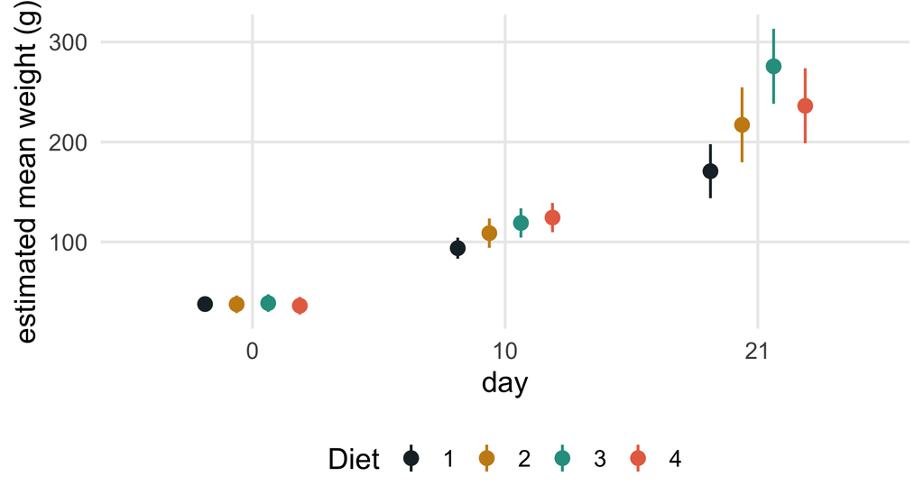

```r
as_tibble(summary(emm)) |>
  ggplot(aes(factor(Time), emmean, color = Diet)) +
  geom_pointrange(aes(ymin = lower.CL, ymax = upper.CL), position = position_dodge(.5), size = .5) +
  scale_color_manual(values = pal_diet) +
  labs(x = "day", y = "estimated mean weight (g)")
```

## Effects plot · each diet across days

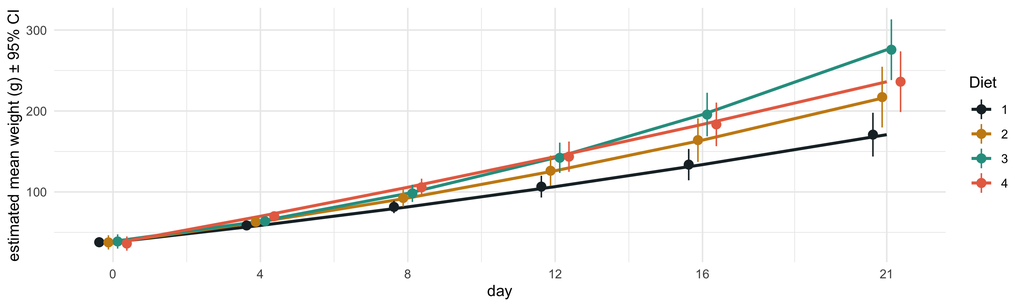

```r
days_grid <- c(0, 4, 8, 12, 16, 21)
emm_grid <- emmeans(m3, ~ Diet | Time, at = list(Time = days_grid)) |> as_tibble()

ggplot(emm_grid, aes(Time, emmean, color = Diet, group = Diet)) +
  geom_line(linewidth = 1) +
  geom_pointrange(aes(ymin = lower.CL, ymax = upper.CL), position = position_dodge(1), size = .5) +
  scale_color_manual(values = pal_diet) +
  scale_x_continuous(breaks = days_grid) +
  labs(x = "day", y = "estimated mean weight (g) ± 95% CI") +
  theme_minimal()
```

One line per diet: **how each diet evolves over time**. Lines that diverge = group × time interaction. Error bars from `emmeans`, so they account for the within-chick correlation.

## Effects plot · each day across diets

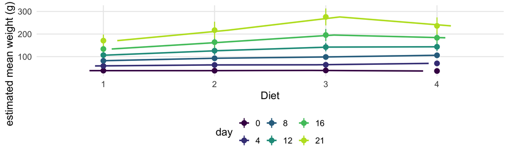

```r
ggplot(emm_grid, aes(Diet, emmean, color = factor(Time), group = factor(Time))) +
  geom_line(linewidth = 1, position = position_dodge(.3)) +
  geom_pointrange(aes(ymin = lower.CL, ymax = upper.CL), size = .5) +
  scale_color_viridis_d("day", end = .9) +
  labs(x = "Diet", y = "estimated mean weight (g) ± 95% CI")
```

Same estimates, axes swapped: one line per day, **how the diets compare on that day**. Flat at day 0 (randomised start), increasingly unequal later: the diet effect **grows with time**.

## Step 2 · All pairwise comparisons

```r
emm21 <- emmeans(m3, ~ Diet, at = list(Time = 21))
pairs(emm21, adjust = "tukey")
```

| contrast | estimate | SE | p |
| --- | --- | --- | --- |
| Diet 1 - Diet 2 | -46.4 | 23.0 | 0.1958 |
| Diet 1 - Diet 3 | -104.9 | 23.0 | 0.0002 |
| Diet 1 - Diet 4 | -65.4 | 23.0 | 0.0322 |
| Diet 2 - Diet 3 | -58.6 | 26.3 | 0.1324 |
| Diet 2 - Diet 4 | -19.0 | 26.4 | 0.8880 |
| Diet 3 - Diet 4 | 39.5 | 26.4 | 0.4459 |

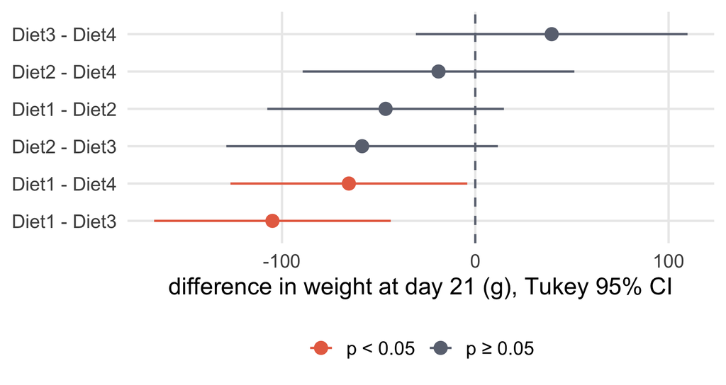

```r
confint(pairs(emm21, adjust = "tukey")) |>
  as_tibble() |>
  left_join(as_tibble(pairs(emm21)) |> select(contrast, p.value), by = "contrast") |>
  mutate(sig = if_else(p.value < .05, "p < 0.05", "p ≥ 0.05"),
         contrast = fct_reorder(contrast, estimate)) |>
  ggplot(aes(estimate, contrast, color = sig)) +
  geom_vline(xintercept = 0, linetype = "dashed", color = "#6b7280") +
  geom_pointrange(aes(xmin = lower.CL, xmax = upper.CL), size = .6) +
  scale_color_manual(NULL, values = c("p < 0.05" = counter, "p ≥ 0.05" = muted)) +
  labs(x = "difference in weight at day 21 (g), Tukey 95% CI", y = NULL)
```

## Step 2b · Each diet vs the control

```r
contrast(emm21, method = "trt.vs.ctrl", ref = 1)
```

```
#>  contrast      estimate SE   df t.ratio p.value
#>  Diet2 - Diet1     46.4 23 46.3   2.019  0.1261
#>  Diet3 - Diet1    104.9 23 46.3   4.568  0.0001
#>  Diet4 - Diet1     65.4 23 46.5   2.845  0.0184
#>
#> Degrees-of-freedom method: kenward-roger
#> P value adjustment: dunnettx method for 3 tests
```

If the question is “**does any new diet beat the standard one?**”, you only need 3 tests, not 6 → Dunnett adjustment → more power.

## Step 2c · The difference curve

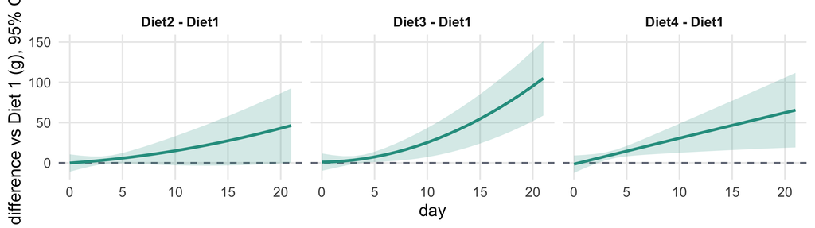

```r
emmeans(m3, ~ Diet | Time, at = list(Time = 0:21)) |>
  contrast(method = "trt.vs.ctrl", ref = 1, adjust = "none") |> confint() |> as_tibble() |>
  ggplot(aes(Time, estimate)) +
  geom_hline(yintercept = 0, linetype = "dashed", color = "#6b7280") +
  geom_ribbon(aes(ymin = lower.CL, ymax = upper.CL), fill = fact, alpha = .2) +
  geom_line(color = fact, linewidth = 1.2) +
  facet_wrap(~ contrast, nrow = 1) +
  labs(x = "day", y = "difference vs Diet 1 (g), 95% CI")
```

## Before the difference of differences: by hand

```r
fixef(m3) |> round(3)
```

```
#>     (Intercept)            Time       I(Time^2)           Diet2
#>          37.862           4.917           0.067          -0.182
#>           Diet3           Diet4      Time:Diet2      Time:Diet3
#>           0.962          -1.622           0.893           0.140
#>      Time:Diet4 I(Time^2):Diet2 I(Time^2):Diet3 I(Time^2):Diet4
#>           3.258           0.063           0.229          -0.003
```

**Your turn**:

1. How many grams does a **Diet 1** chick gain from day 0 to day 21? And a **Diet 3** chick?
2. How much **more** does Diet 3 gain than Diet 1?
3. Compare with the difference at day 21 (≈ 105 g). Why are they not exactly equal?

## Step 2d · Difference of differences

The **group × time interaction** as one number: how much more did Diet *k* chicks **gain** from day 0 to day 21 than Diet 1 chicks?

```r
emm_0_21 <- emmeans(m3, ~ Diet * Time, at = list(Time = c(0, 21)))
contrast(emm_0_21, interaction = c(Diet = "trt.vs.ctrl", Time = "trt.vs.ctrl"))
```

```
#>  Diet_trt.vs.ctrl Time_trt.vs.ctrl estimate   SE   df t.ratio p.value
#>  2 - 1            21 - 0               46.6 27.1 45.6   1.718  0.0925
#>  3 - 1            21 - 0              104.0 27.1 45.6   3.837  0.0004
#>  4 - 1            21 - 0               67.0 27.1 45.7   2.472  0.0172
#>
#> Degrees-of-freedom method: kenward-roger
```

$[\mu_{21}(k) - \mu_{0}(k)] - [\mu_{21}(1) - \mu_{0}(1)]$: change in Diet *k* **minus** change in Diet 1. Diet 3 gains **≈104 g more** than Diet 1.

## Before `emtrends`: by hand

**Your turn**, with `fixef(m3)` (remember: rate at day *t* = slope + 2 · curvature · *t*):

1. Growth rate of **each diet** at **day 10**?
2. Diets 3 and 4 at day 10: which grows faster, and by how much?
3. Is that difference significant? What would you need?

## Step 3 · Rates of growth by diet: `emtrends`

```r
slopes10 <- emtrends(m3, ~ Diet, var = "Time", at = list(Time = 10))
slopes10
pairs(slopes10)
```

| Diet | g/day | 95% CI |
| --- | --- | --- |
| 1 | 6.26 | 4.7–7.8 |
| 2 | 8.42 | 6.3–10.5 |
| 3 | 10.99 | 8.9–13.1 |
| 4 | 9.46 | 7.3–11.6 |

| contrast | estimate | SE | p |
| --- | --- | --- | --- |
| Diet1 - Diet2 | -2.16 | 1.29 | 0.3510 |
| Diet1 - Diet3 | -4.73 | 1.29 | 0.0035 |
| Diet1 - Diet4 | -3.19 | 1.29 | 0.0776 |
| Diet2 - Diet3 | -2.57 | 1.48 | 0.3187 |
| Diet2 - Diet4 | -1.04 | 1.48 | 0.8964 |
| Diet3 - Diet4 | 1.53 | 1.48 | 0.7313 |

## Step 3b · …and how the rate evolves

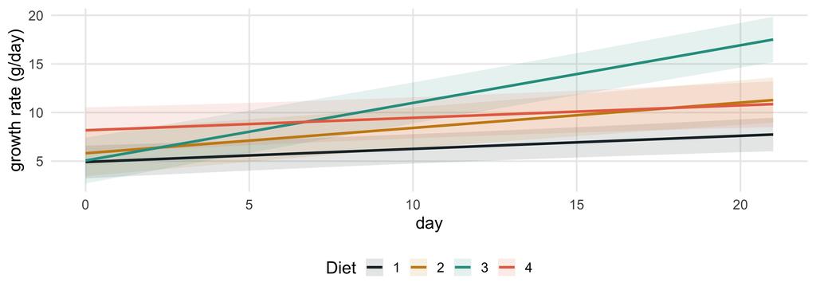

```r
emtrends(m3, ~ Diet | Time, var = "Time", at = list(Time = 0:21)) |>
  as_tibble() |>
  ggplot(aes(Time, Time.trend, color = Diet, fill = Diet)) +
  geom_ribbon(aes(ymin = lower.CL, ymax = upper.CL), alpha = .12, color = NA) +
  geom_line(linewidth = 1.1) +
  scale_color_manual(values = pal_diet) + scale_fill_manual(values = pal_diet) +
  labs(x = "day", y = "growth rate (g/day)")
```

**Diet 4** starts fastest but barely accelerates; **Diet 3** accelerates most and overtakes it after about a week. That’s the story behind `Time:Diet4` and `I(Time^2):Diet3`, now readable.

## Marginal vs conditional, by diet

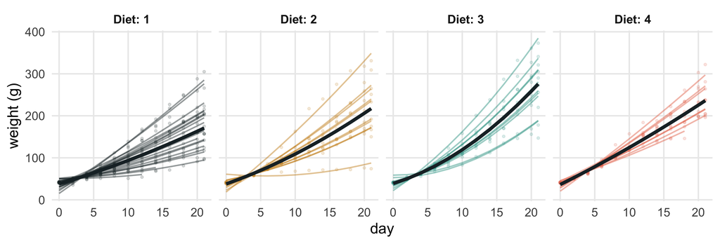

```r
chicks |>
  mutate(chick_curve = predict(m3),                  # Xβ + Zb_i  (conditional)
         pop_curve   = predict(m3, re.form = NA)) |> # Xβ         (marginal)
  ggplot(aes(Time, color = Diet)) +
  geom_point(aes(y = weight), alpha = .15, size = .8) +
  geom_line(aes(y = chick_curve, group = Chick), alpha = .45) +
  geom_line(aes(y = pop_curve), linewidth = 1.6, color = ink) +
  facet_wrap(~ Diet, nrow = 1, labeller = label_both) +
  scale_color_manual(values = pal_diet, guide = "none") +
  labs(x = "day", y = "weight (g)")
```

Thin lines: each chick’s curve, $X\hat\beta + Z\hat b_i$. Thick line: each diet’s population curve, $X\hat\beta$.

Block 7 · Practice again

7

## Your turn: Orthodont

Do boys and girls grow at a different rate?

## Exercise

`nlme::Orthodont`: distance (mm) from the pituitary to the pterygomaxillary fissure in **27 children** (16 boys, 11 girls) at ages **8, 10, 12, 14** (Potthoff and Roy 1964).

1. Spaghetti plot by `Sex` and profile means
2. Random intercept vs intercept + slope, with `distance ~ age_c * Sex`. Which one?
3. `emmeans`: boys vs girls at 8 and at 14.
4. `emtrends`: growth (mm/year) by sex. Different?
5. `ggpredict()`: plot both curves.
6. Bootstrap CI for the SD of the slopes.

## References

Belenky, Gregory, Nancy J. Wesensten, David R. Thorne, Maria L. Thomas, Helen C. Sing, Daniel P. Redmond, Michael B. Russo, and Thomas J. Balkin. 2003. “Patterns of Performance Degradation and Restoration During Sleep Restriction and Subsequent Recovery: A Sleep Dose-Response Study.” *Journal of Sleep Research* 12 (1): 1–12.

Crowder, Martin J., and David J. Hand. 1990. *Analysis of Repeated Measures*. Chapman; Hall.

Lenth, Russell V. 2024. *emmeans: Estimated Marginal Means, Aka Least-Squares Means*. https://CRAN.R-project.org/package=emmeans.

Potthoff, Richard F., and S. N. Roy. 1964. “A Generalized Multivariate Analysis of Variance Model Useful Especially for Growth Curve Problems.” *Biometrika* 51 (3/4): 313–26.